# Final report

## Step 4: Identify

**Back-door criterion**  
The causal parameter $\theta^*$ is identified if there is equivalence between the causal parameter $\theta^*$ and some statistical parameter $\theta$, for each P* compatible with SCM. We assess the identifiability of $\theta^*$ using the back-door criterion. We need W block any association between A and Y that from common causes; W does not create any new non-causal associations between A and Y; W does not block any of the effect of A on Y. We used the graphic method to check if variables satisfy the back-door criterion. Since there is no independence assumption on $P^*$, there are arrows between each of the exogenous variables, which also contains some backdoor paths. There isn’t a subset of observed covariates W that satisfies the back-door criterion. The $\theta^*$ is not identified.

**Randomization assumption**  
To identify the $\theta^*$, We need the randomization assumption: $Y_a \perp \!\!\! \perp A|W$. Under this assumption, $E^*(Y_a) = E[E(Y | A = a,W)]$. Conditional on covariates W, we want to be sure that any observed association between A and Y is due to the effect of the exposure A on the outcome Y. The randomization assumption holds under these set of independence assumptions: $U_A \perp \!\!\! \perp U_Y,\ and \ (U_{W} \perp \!\!\! \perp U_Y , or\ \ U_A \perp \!\!\! \perp U_{W})$.

- According to the DAG,
  - No node of W is a descendant of A: there is no spurious sources association between A and Y.
  - W blocks all “back-door” paths from A to Y: there is no spurious sources of dependence and W didn’t block the path of interest.

Then W satisfy the back-door criterion. $\theta^*$ is identified.

## Step 5: Commit to a Statistical Model and Estimand

**Statistical model**  
The statistical model is set of possible distributions of the observed data. The causal model implies the statistical model. Our causal model represent our knowledge about how the observed data was generated, but this knowledge does not imply any restrictions on the set of possible observed data distributions. The structural equations do not restrict the functional form of the causal relationships. So there is no restrictions on the distributions of the observed data, our statistical model is non-parametric.

**Estimand**

- $\theta^*$: causal parameter/estimand  
  The target causal parameter is $\theta^*=Ε^*(Y_1-Y_0)=E^*[f_Y(W,1,U_Y)]-E^*[f_Y(W,0,U_Y)]$. It is the property of the counterfactual distribution.
- $\theta$: statistical parameter/estimand
  The statistical estimand is calculated from true observed population(property of true observed data distribution), could know if we have infinite data.
  $$\begin{align}
  \theta &=E[E(Y|A=1,W)-E(Y|A=0,W)] \\
  &=\sum_W[E(Y|A=1,W=w)-E(Y=0,W=w)]P(W=w)
  \end{align}$$
- $\hat{\theta}$: estimator of statistical estimand
  - The estimator is calculated from our observed data set. It is the estimator of statistical estimand. It could be estimator of causal parameter if W satisfies the back-door criterion and positivity assumption(identification) and if the model is indeed as specified(statistical model representing real knowledge).
  - Because of curse of dimensionality, we can’t use non-parametric estimator when covariates W are high-dimensional. We could use a priori-specified parametric regression. But if we rely on mis-specified parametric regressions, we would got poor estimators. The estimator that does not respect the statistical model would have large bias, and misleading inference. However, looking at the data in an ad hoc way is dangerous, the estimator must be an a priori-specified algorithm, or it would introduce bias and misleading inference. Thus, we consider discrete super learner to choose the algorithm with the lowest cross-validated risk estimate. So we can do better job estimating E(Y|A,W) and P(A,W). In our study, we calculate 4 estimators using SuperLearner. Substitution and IPW with SuperLearner: wrong bias-variance trade-off, no formula for CIs and p-values. Augmented IPW and TMLE: use SuperLearner to solve model misspecification bias, while still allowing computation of CIs and p-values.
    - Simple substitution estimator
      $$\hat{\theta}_{G-formula} =\hat{\theta}=\sum_w[E_n(Y|A=1,W=w)-E_n(Y|A=0,W=w)]P_n(W=w)$$
    - IPTW estimator
      $$\hat{\theta}_{IPTW} =\frac{1}{n}\sum_{i=1}^n\frac{I(A_i=a)}{\hat{P}(A_i=a|W_i)}Y_i$$
    - AIPW
      $$\hat{\theta}_{AIPW} = \frac{1}{n}\sum^n_{i=1}\{\frac{A_i}{\hat{g}(W_i)}[Y_i-\hat{m}(W_i)]+\hat{m}(W_i)\}$$
    - TMLE
      $$\tilde{m}(A,W) = expit \bigg[ logit\big[ \hat{m}(A,W) \big] + \hat{\epsilon} \hat{H}(A,W) \bigg]$$
      $$\hat{\theta}_{TMLE} = \frac{1}{n} \sum_{i=1}^n \bigg[ \tilde{m}(A,W) \bigg]$$

## Step 6: Estimates

**Unajusted Result**

First, we use the raw data to calculate the causal effect of exercise on depression level without covariates. Then using T-Test to calculate its 95% confidence interval.

**SuperLearner**

We use SuperLearner to calculate G-computation (simple substitution estimator), inverse probability of treatment weighted estimator(IPTW), AIPW, and TMLE.

For the library of the SuperLearner, we choose `SL.glm`, `SL.glmnet`, `SL.earth`, `SL.randomForest` and `SL.mean` as the algorithms. `SL.glm` is the basic function to built a generalized linear model, so we pick it in the library. Considering lots of covariates and little background knowledge about their relationship, we added `SL.glmnet`, `SL.earth`, `SL.randomForest` and `SL.mean` to the library to reduce some non-significant or less associate covariates to improve the performance of the prediction.

We only provided 95% confidence interval for AIPW and TMLE, as the standard error for other methods can not be calculated in this way.

**CV SuperLearner**

Then we use cross-validation SuperLearner to figure out the coefficient of each algorithms of each fold (5 fold cross validation).

### Outcome

According to the bellow plot, we can see the risk of `SL.glmenet` and `SL.mean` is lowest among those functions (around 0.15). Moreover, the coefficient table shows that `SL.glmenet` and `SL.mean` have the largest coefficients.

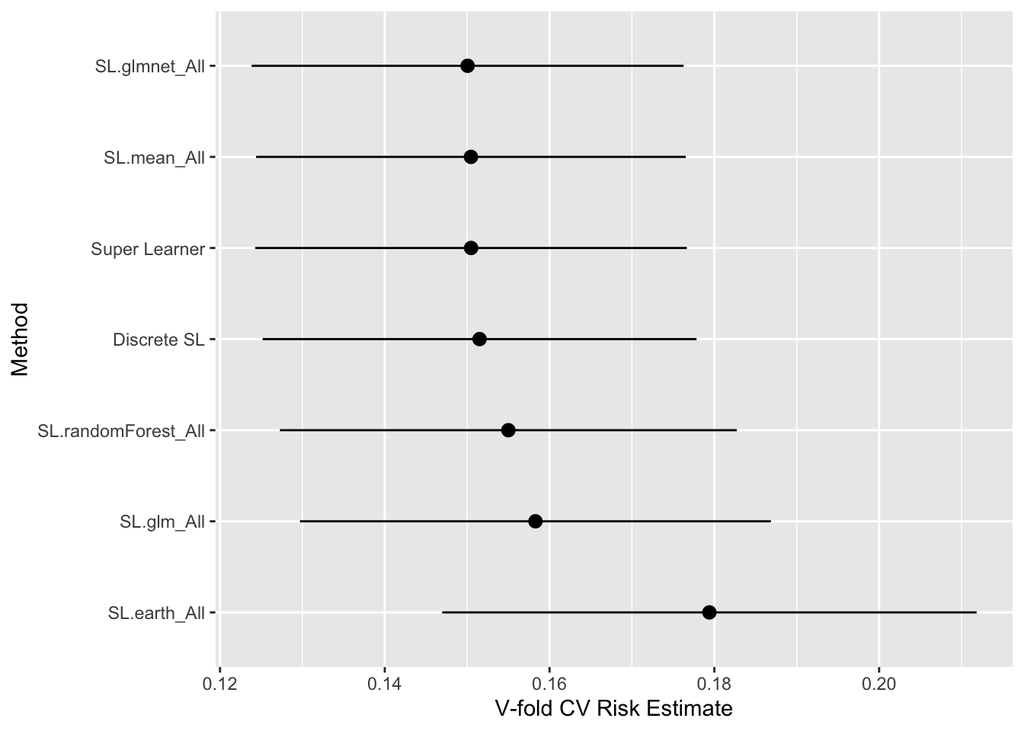

| CV_fold | SL.glm_All | SL.glmnet_All | SL.earth_All | SL.randomForest_All | SL.mean_All |
| --- | --- | --- | --- | --- | --- |
| 1 | 0.0000000 | 1 | 0.0000000 | 0.0000000 | 0.0000000 |
| 2 | 0.3244412 | 0 | 0.0000000 | 0.0000000 | 0.6755588 |
| 3 | 0.0000000 | 0 | 0.0432135 | 0.2910952 | 0.6656912 |
| 4 | 0.2050365 | 0 | 0.1977047 | 0.0000000 | 0.5972588 |
| 5 | 0.1640289 | 0 | 0.1164528 | 0.1972129 | 0.5223054 |

### Exposure

According to the following plot, we can see the risk of `SL.mean` is lowest among those functions (risk = 0.228). Moreover, the coefficient table shows that `SL.mean` have the largest coefficients.

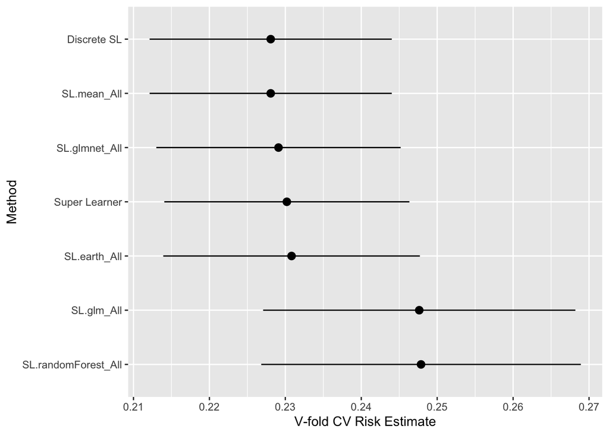

| CV_fold | SL.glm_All | SL.glmnet_All | SL.earth_All | SL.randomForest_All | SL.mean_All |
| --- | --- | --- | --- | --- | --- |
| 1 | 0.2694264 | 0 | 0.0131596 | 0.0000000 | 0.7174141 |
| 2 | 0.0000000 | 0 | 0.0000000 | 0.0839994 | 0.9160006 |
| 3 | 0.0000000 | 0 | 0.6374551 | 0.0000000 | 0.3625449 |
| 4 | 0.0000000 | 0 | 0.0000000 | 0.2241904 | 0.7758096 |
| 5 | 0.0000000 | 1 | 0.0000000 | 0.0000000 | 0.0000000 |

**Check the positivity assumption**

[output not shown]

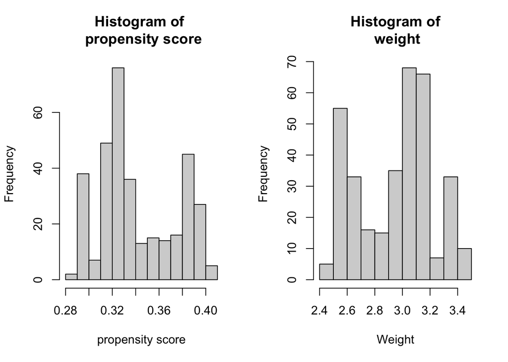

As the corresponding non-stabilized weights range from 2 to 4, there is no extreme weight. Therefor, we do not add truncation to the corresponding non-stabilized weights.

**Non-parametric bootstrap of IPTW and TMLE**

We used the non-parametric bootstrap to estimate IPTW and TMLE as well as their 95% confidence intervals.

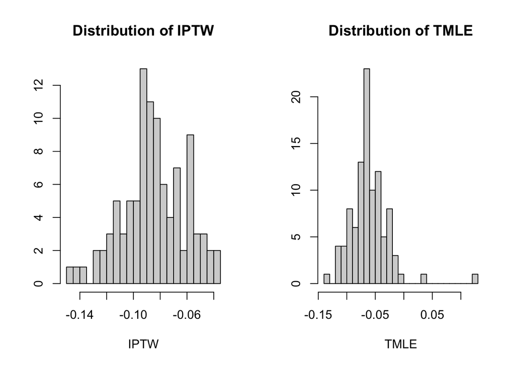

From the plots, we can see the distribution of IPTW is skewed, which range form -0.15 to 0. For TMLE, the distribution is kind of normal distribution with a right tail, which range from -0.15 to 0.15.

**TMLE package**

We also use TMLE package to estimate the tmle and the corresponding 95% CI by the function.

Below is our estimates table, including all estimators and corresponding 95% CI:

**Estimates Table**

| Method | Estimate | 95% CI |
| --- | --- | --- |
| Unajusted Result | -0.06038 | (-0.14344,0.02269) |
| G-computation | -0.01302 |  |
| IPTW | -0.06758 |  |
| Non-parametric boot IPTW | -0.08476 | (-0.13245,-0.04235) |
| AIPW | -0.04820 | (-0.11937,0.02297) |
| TMLE | -0.02454 | (-0.09584,0.04677) |
| Non-parametric boot TMLE | -0.06064 | (-0.11409,-0.00541) |
| TMLE by tmle package | -0.05201 | (-0.13289,0.02887) |